# Assignment 6

## Try to submit as an HTML file

Print your Emory ID below

```python
print(2626784)
```

```
2626784
```

Import the "pandas" and "matplotlib.pyplot" library

```python
# Write your answer here:
import pandas as pd
import matplotlib.pyplot as plt
import numpy as np
```

(a) Compute function for each individual (map)

- Import the datset "data/bmi.csv"
  - **Note that the column `Height` is in $cm$, and `Weight` is in $kg$**
- Write a lambda function for $ BMI = \frac{weight (kg)}{height (m)^2} $
- Use `list(map(...))` to calculate $BMI$ for each row of the dataset
- Round the outcome into 2 decimal points
- Store the calculation in a new column in the dataframe called `BMI`
- Display the dataframe

```python
# Write your own code here
bmi_dataset = pd.read_csv("data/bmi.csv")
bmi_dataset['height_m']=bmi_dataset['Height']*0.01
fn_bmi = lambda height, weight: weight/(height**2)

df=pd.DataFrame()
df["BMI"] = np.round(list(map(fn_bmi, bmi_dataset['height_m'], bmi_dataset['Weight'])), 2)


display(df)
```

|  | BMI |
| --- | --- |
| 0 | 31.71 |
| 1 | 24.36 |
| 2 | 32.14 |
| 3 | 27.35 |
| 4 | 27.48 |
| ... | ... |
| 495 | 68.00 |
| 496 | 35.74 |
| 497 | 68.41 |
| 498 | 42.22 |
| 499 | 43.77 |

500 rows × 1 columns

For questions (b)-(d), read "data/wdi_2020.csv"

- This is a dataset containing the proportion  
  of urban population by country in 2020

```python
dataset = pd.read_csv("data/wdi_2020.csv")
dataset
```

|  | year | yearcode | countryname | countrycode | prop_urbanpopulation |
| --- | --- | --- | --- | --- | --- |
| 0 | 2020 | YR2020 | Afghanistan | AFG | 26.026000 |
| 1 | 2020 | YR2020 | Africa Eastern and Southern | AFE | 36.828301 |
| 2 | 2020 | YR2020 | Africa Western and Central | AFW | 47.857831 |
| 3 | 2020 | YR2020 | Albania | ALB | 62.112000 |
| 4 | 2020 | YR2020 | Algeria | DZA | 73.733000 |
| ... | ... | ... | ... | ... | ... |
| 261 | 2020 | YR2020 | West Bank and Gaza | PSE | 76.719000 |
| 262 | 2020 | YR2020 | World | WLD | 56.063764 |
| 263 | 2020 | YR2020 | Yemen, Rep. | YEM | 37.908000 |
| 264 | 2020 | YR2020 | Zambia | ZMB | 44.629000 |
| 265 | 2020 | YR2020 | Zimbabwe | ZWE | 32.242000 |

266 rows × 5 columns

(b) Convert to upper case

- Create the following function to convert a string to upper case

$\quad$ `fn_upper = lambda x: x.upper()`

- Create a new column, "countryname_upper"  
  that converts "countryname" to upper case.
- Print the original `countryname` and the newly created column, like:  
  "['Afghanistan', 'Africa Eastern and Southern', 'Africa Western and Central', 'Albania', 'Algeria', ......] "

```python
# Write your own code here
fn_upper = lambda x: x.upper()
dataset["countryname_upper"]=list(map(fn_upper, dataset["countryname"]))
print(dataset["countryname"].array)
print(dataset["countryname_upper"].array)
```

```
<PandasArray>
[                'Afghanistan', 'Africa Eastern and Southern',
  'Africa Western and Central',                     'Albania',
                     'Algeria',              'American Samoa',
                     'Andorra',                      'Angola',
         'Antigua and Barbuda',                  'Arab World',
 ...
                  'Uzbekistan',                     'Vanuatu',
               'Venezuela, RB',                     'Vietnam',
       'Virgin Islands (U.S.)',          'West Bank and Gaza',
                       'World',                 'Yemen, Rep.',
                      'Zambia',                    'Zimbabwe']
Length: 266, dtype: object
<PandasArray>
[                'AFGHANISTAN', 'AFRICA EASTERN AND SOUTHERN',
  'AFRICA WESTERN AND CENTRAL',                     'ALBANIA',
                     'ALGERIA',              'AMERICAN SAMOA',
                     'ANDORRA',                      'ANGOLA',
         'ANTIGUA AND BARBUDA',                  'ARAB WORLD',
 ...
                  'UZBEKISTAN',                     'VANUATU',
               'VENEZUELA, RB',                     'VIETNAM',
       'VIRGIN ISLANDS (U.S.)',          'WEST BANK AND GAZA',
                       'WORLD',                 'YEMEN, REP.',
                      'ZAMBIA',                    'ZIMBABWE']
Length: 266, dtype: object
```

(c) Extract sorted elements from a dataset

- Sort by "prop_urbanpopulation" in ascending order
- Subset the 5 countries with the lowest urban population

```python
# Write your code here
ascendingpop = dataset.sort_values(by="prop_urbanpopulation", ascending=True)
ascendingpop.iloc[:5]
```

|  | year | yearcode | countryname | countrycode | prop_urbanpopulation | countryname_upper |
| --- | --- | --- | --- | --- | --- | --- |
| 191 | 2020 | YR2020 | Papua New Guinea | PNG | 13.345 | PAPUA NEW GUINEA |
| 34 | 2020 | YR2020 | Burundi | BDI | 13.708 | BURUNDI |
| 141 | 2020 | YR2020 | Liechtenstein | LIE | 14.416 | LIECHTENSTEIN |
| 177 | 2020 | YR2020 | Niger | NER | 16.626 | NIGER |
| 149 | 2020 | YR2020 | Malawi | MWI | 17.427 | MALAWI |

(d) Subset elements with query

**hint: Import `numpy` and use `np.nanpercentile`**

```python
# Write your own code here
standard =np.nanpercentile(dataset['prop_urbanpopulation'],25)
print(standard)
dataset.query("prop_urbanpopulation < @standard")
```

```
42.492392115
```

|  | year | yearcode | countryname | countrycode | prop_urbanpopulation | countryname_upper |
| --- | --- | --- | --- | --- | --- | --- |
| 0 | 2020 | YR2020 | Afghanistan | AFG | 26.026000 | AFGHANISTAN |
| 1 | 2020 | YR2020 | Africa Eastern and Southern | AFE | 36.828301 | AFRICA EASTERN AND SOUTHERN |
| 8 | 2020 | YR2020 | Antigua and Barbuda | ATG | 24.433000 | ANTIGUA AND BARBUDA |
| 18 | 2020 | YR2020 | Bangladesh | BGD | 38.177000 | BANGLADESH |
| 19 | 2020 | YR2020 | Barbados | BRB | 31.191000 | BARBADOS |
| ... | ... | ... | ... | ... | ... | ... |
| 249 | 2020 | YR2020 | Uganda | UGA | 24.954000 | UGANDA |
| 257 | 2020 | YR2020 | Vanuatu | VUT | 25.525000 | VANUATU |
| 259 | 2020 | YR2020 | Vietnam | VNM | 37.340000 | VIETNAM |
| 263 | 2020 | YR2020 | Yemen, Rep. | YEM | 37.908000 | YEMEN, REP. |
| 265 | 2020 | YR2020 | Zimbabwe | ZWE | 32.242000 | ZIMBABWE |

66 rows × 6 columns

(e) Plot by category

- Read "data/wdi_urban.csv"  
  This contains data from 1980 and 2020
- Create a list with the unique values of "year"
- Create a plot with a ...
  - Histogram of "prop_urbanpopulation"  
    for each year
  - Set the histogram option `alpha = 0.5` for transparency
  - All the histograms should be overlapping
  - Create a legend with the list of years
  - Label the axes and the title

What do we learn from the graph?

HINT: See the example at the end of Lecture 10

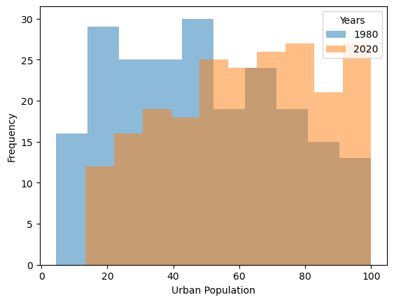

```python
# Write your own code here
urban_ds=pd.read_csv("data/wdi_urban.csv")
year_list = pd.unique(urban_ds["year"])

for year in year_list:
    df = urban_ds.query("@year == year")
    plt.hist(x=df["prop_urbanpopulation"], alpha=0.5)

plt.legend(labels=year_list, title="Years")
plt.xlabel("Urban Population")
plt.ylabel("Frequency")
plt.show()

##We learn that the urban population in countries have generally grown from 1980 to 2020
```